CS F364: Design & Analysis of Algorithms

# Introduction to Sorting & Asymptotic Analysis

Lecture 2 |2026-05-21

Dr. Tulasimohan Molli BITS Pilani, Hyderabad Campus

# Introduction to Sorting

- Introduction to Sorting
- Asymptotic Analysis
- Wrap-up

## Takeaway from last class…

- Algorithms are powerful!
- Algorithm designer’s question: Can we do better?
- interplay between rigor and intuition.

## Introduction

**Sorting**

Re-arranging similar elements in a preferred order:

Either - increasing order or - decreasing order or - Lexicographic order

## Bubble Sort-Description

Simplest sorting technique to arrange elements in the ascending order:

- **Start at the beginning:** Compare the first two elements.
- **Compare and Swap:** If the first element is greater than the second, swap them or leave them as they are.
- **Move to the next pair:** Move to the next pair of elements and repeat the compare and swap operations.
- **Continue to the end of the list:** Repeat the above step until you reach the end of the list.
- **Repeat:** Go back to the beginning of the list and do the above four steps following the sequence.
- **Stop:** Terminate when there is not a single swap operation in the current pass.

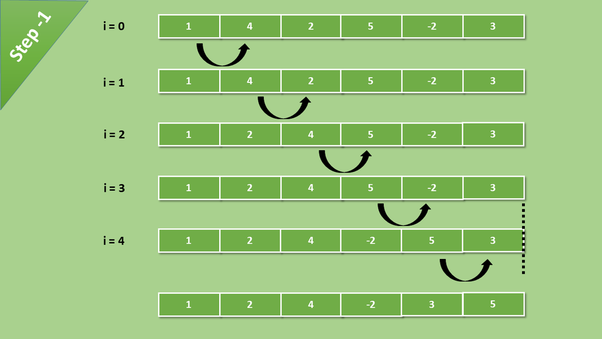

## Bubble Sort-Pass-2

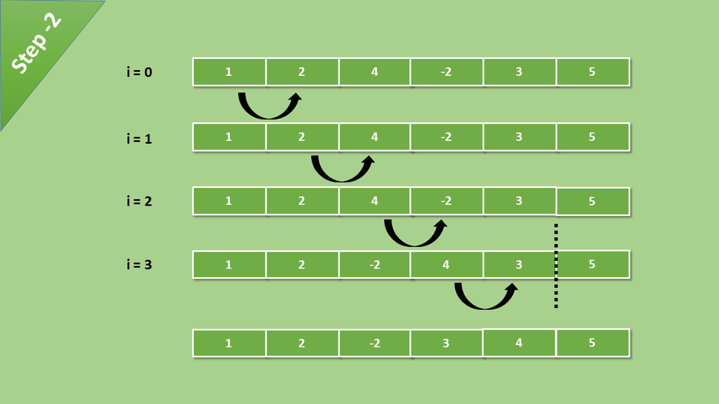

## Bubble Sort-Pass-3

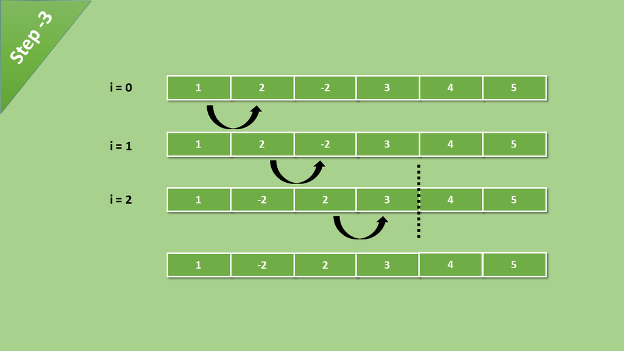

## Bubble Sort-Pass-4

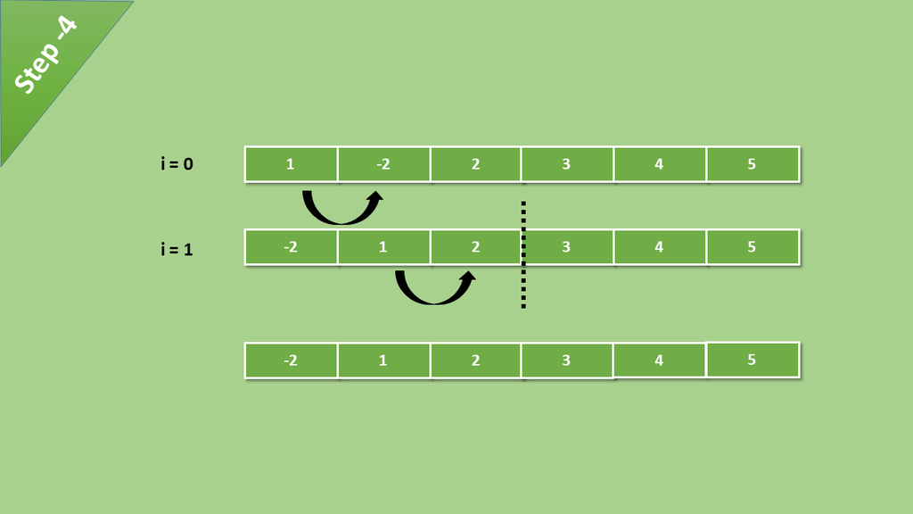

## Bubble Sort-Pass-5

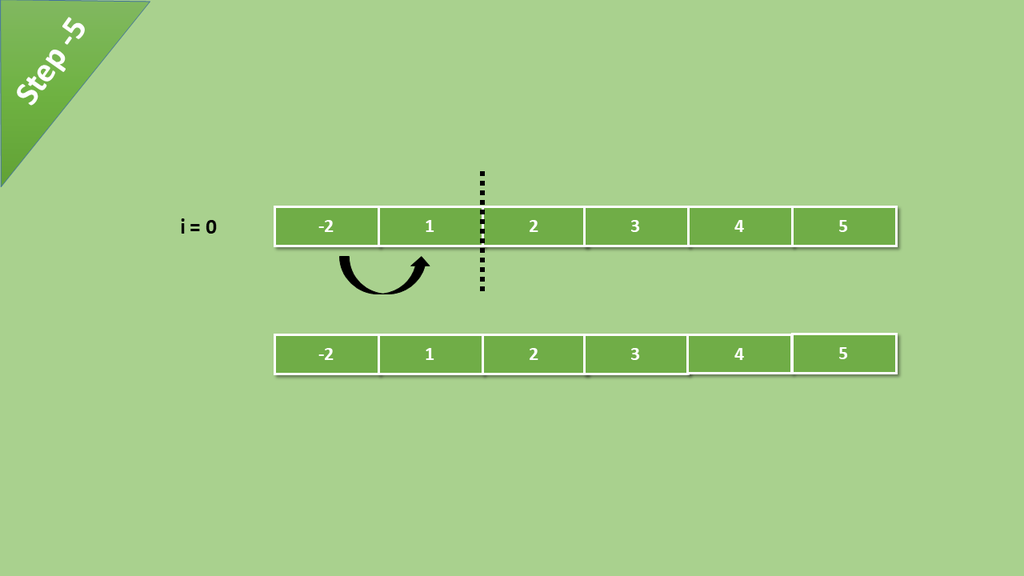

## Bubble Sort-Algorithm-Implementation

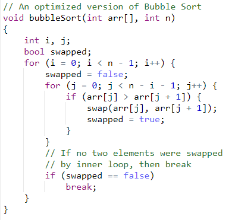

## Bubble Sort-Example

Example: 7, 4, 8, 2, 5, 3, 9

- **Pass-1:** 4, 7, 2, 5, 3, 8, **9**.
- **Pass-2:** 4, 2, 5, 3, 7, **8, 9**.
- **Pass-3:** 2, 4, 3, 5, **7, 8, 9**.
- **Pass-4:** 2, 3, 4, **5, 7, 8, 9**.
- **Pass-5:** **2, 3, 4, 5, 7, 8, 9**.

## Bubble Sort-Time complexity

- Outer loop iterates $n$ times.
- At $i^{th}$ iteration of the outer loop, inner loop iterates at most $n-i$ times.
- Overall time complexity in the worst case is $1+2+3+...+(n-1) = O(n^2)$.

## Insertion Sort-Description

1. **Start with the first element:** Consider the first element as a sorted sublist.
2. **Select the next element:** Take the next element in the list.
3. **Find the correct position:** Compare this element with the elements in the sorted sublist from right to left.
4. **Shift elements:** Shift all elements in the sorted sublist that are greater than the current element one position to the right.
5. **Insert the element:** Insert the current element into its correct position in the sorted sublist.
6. **Repeat:** Repeat steps $2$ to $5$ for each of the remaining elements in the list.

## Insertion Sort

Example: 4 3 2 10 12 1 5 6

## Insertion Sort

Example: 4 3 2 10 12 1 5 6

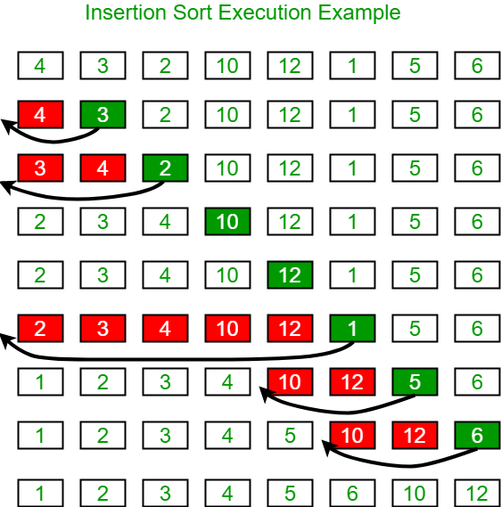

## Insertion Sort-Algorithm-Implementation

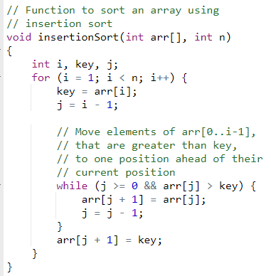

## Insertion sort-time complexity

- $n$ iterations in the outer loop.
- around $n$ iterations in the inner loop.

Overall time complexity is around $n^2$.

## Can we do better?

- MergeSort: A **divide-and-conquer** approach.
- Recall the following picture from the last time:

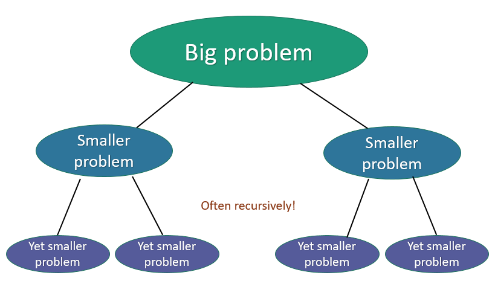

## Mergesort

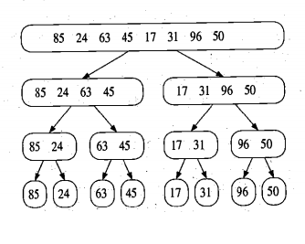

## Mergesort

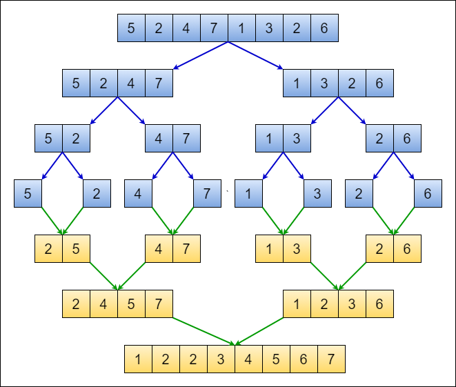

MERGE SORT ( A, p, r)

- if $p<r$ then
  - $q=\lfloor(p+r)/2\rfloor$
  - MERGE SORT ( A, p, q)
  - MERGE SORT ( A, q + 1, r)
  - create subarrays $S_1$ and $S_2$
  - Merge ($S_1$,$S_2$,A)

Time complexity of MergeSort is around $n\log{n}$.  
We will come back to the analysis and correctness proof little later!

## $n\log{n}$ vs $n^2$

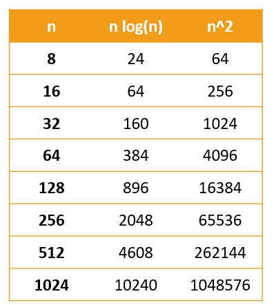

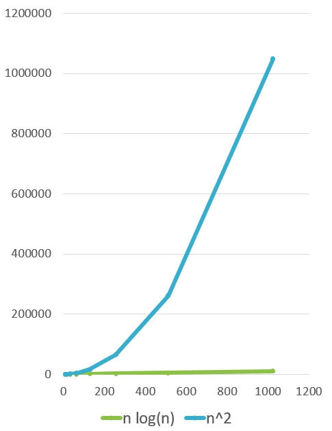

# Asymptotic Analysis

- Introduction to Sorting
- Asymptotic Analysis
- Wrap-up

## Introduction - Asymptotic analysis

- The order of growth of the running time of an algorithm gives a simple characterization of the algorithm’s efficiency.
- **Asymptotic efficiency:** We are concerned with how the running time of an algorithm increases with the size of the input *in the limit*, as the size of the input inreases without bound.
- An algorithm is asymptotically more efficient will be the best choice for all but very small inputs.
- Asymptotic running time of an algorithm are defined in terms of functions whose domains are the set of natural numbers $N=\{0, 1, 2, \ldots\}$. Such notations are convenient for describing the worst-case running-time funcion $T(n)$, which is usually defined only on integer input sizes.

## Big Oh

**$O$-notation**

For a given function $g(n)$, we denote by $O(g(n))$ the set of functions  
$O(g(n)) = \{f(n) : \text{there exists positive constants } c \text{ and } n_0 \text{ such that } 0\leq f(n)\leq cg(n) \text{ for all } n\geq n_0\}$.

- We use $O$-notation when we have only an **asymptotic upper bound**.

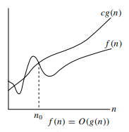

## Big Oh Examples

- $3n^2-100n+10 = O(n^2)$ because $3n^2 > 3n^2-100n+10$.
- $3n^2-100n+10 = O(n^3)$ because $0.01n^3 > 3n^2-100n+10$.
- $3n^2-100n+10\neq O(n)$ because $c\cdot n < 3n^2$ when $n>c$.

## Big Omega

**$\Omega$-notation**

For a given function $g(n)$, we denote by $\Omega(g(n))$ the set of functions  
$\Omega(g(n)) = \{f(n) : \text{there exists positive constants } c \text{ and } n_0 \text{ such that } 0\leq cg(n)\leq f(n) \text{ for all } n\geq n_0\}$.

- We use $\Omega$-notation when we have only an **asymptotic lower bound**.

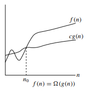

## Big Omega Examples

- $3n^2-100n+10 = \Omega(n^2)$ because $2.99n^2 < 3n^2-100n+10$.
- $3n^2-100n+10\neq\Omega(n^3)$ because $3n^2-100n+10 < n^3$.
- $3n^2-100n+10 = \Omega(n)$ because $10^{10^{10}}n < 3n^2-100n+10$.

## Big Theta

**$\Theta$-notation**

For a given function $g(n)$, we denote by $\Theta(g(n))$ the set of functions  
$\Theta(g(n)) = \{f(n) : \text{there exists positive constants } c_1, c_2, \text{ and } n_0 \text{ such that } 0\leq c_1g(n)\leq f(n)\leq c_2g(n) \text{ for all } n\geq n_0\}$.

- The $\Theta$-notation asymptotically bounds a function from above and below.

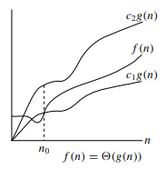

## Big Theta Example

- $3n^2-100n+10 = \Theta(n^2)$ because of $O$ and $\Omega$.
- $3n^2-100n+10\neq\Theta(n^3)$ because of $O$ only.
- $3n^2-100n+10\neq\Theta(n)$ because of $\Omega$ only.

# Wrap-up

- Introduction to Sorting
- Asymptotic Analysis
- Wrap-up

## Discussion Time!

Thank You!

Let’s discuss questions, clarifications, or any topics from today’s lecture.